# Medidas Bivariantes

Estadística Descriptiva

11/12/2020

Después de estudiar cómo hay que organizar, representar gráficamente y analizar un conjunto de datos a partir de algunos parámetros, nos proponemos estudiar las relaciones entre variables. Por ejemplo, podemos determinar si existe alguna relación entre la variables peso y altura de un conjunto de personas.

Pretendemos estudiar una situación muy usual y por tanto de gran interés en la práctica: Si $Y$ es una variable definida sobre la misma población que $X$, ¿será posible determinar si existe alguna relación entre las modalidades de $X$ y de $Y$?

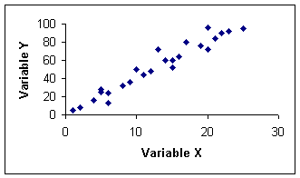

En este tema se presentan el **coeficiente de correlación** y la **regresión lineal simple** como las dos técnicas estadísticas más utilizadas para investigar la relación entre dos variables continuas $X$ e $Y$.

Gráficamente el **diagrama de dispersión** o nube de puntos permite obtener información sobre el tipo de relación existente entre $X$ e $Y$, además de ayudarnos a detectar posibles valores atípicos o *outliers*.

Las técnicas de correlación y las de regresión están estrechamente relacionadas, aunque obedecen a estrategias de análisis un tanto diferentes.

Por un lado, el *coeficiente de correlación* determina el grado de asociación lineal entre $X$ e $Y$. Por el contrario, la regresión lineal simple permite cuantificar el cambio en el nivel medio de la variable $Y$ conforme cambia la variable $X$, asumiendo implícitamente que $X$ es la **variable explicativa o independiente** e $Y$ es la **variable respuesta o dependiente**.

## Correlación Lineal

La finalidad de la **correlación** es examinar la dirección y la fuerza de la asociación entre dos variables cuantitativas. Así conoceremos la intensidad de la relación entre ellas y *si, al aumentar el valor de una variable, aumenta o disminuye el valor de la otra variable*.

Para valorar la asociación entre dos variables, la primera aproximación suele hacerse mediante un diagrama de dispersión.

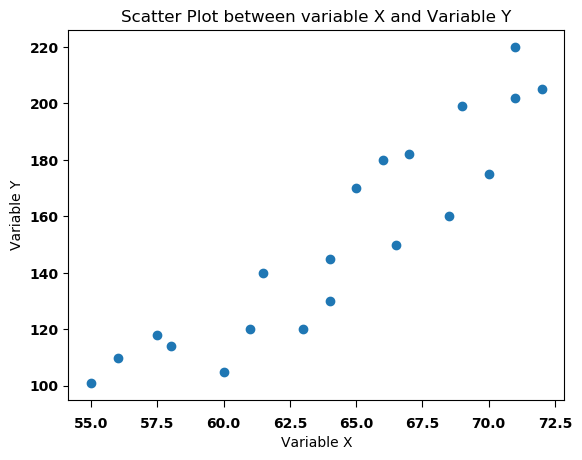

En el diagrama de dispersión de la figura anterior parece existir una relación lineal entre la variable $X$ y la variable $Y$ de un conjunto de datos.

Hay dos **coeficientes de correlación** que se usan frecuentemente: el de **Pearson** (paramétrico) y el de **Spearman** (no paramétrico, se utiliza en aquellos casos donde las variables examinadas no cumplen criterios de normalidad o cuando las variables son ordinales).

Nos vamos a concentrar en el coeficiente de correlación de Pearson, el cual evalúa específicamente la adecuación a la recta lineal que defina la relación entre dos variables cuantitativas. El coeficiente no paramétrico de Spearman mide cualquier tipo de asociación, no necesariamente lineal.

> Si se desea **medir o cuantificar el grado de asociación** entre dos variables cuantitativas se debe calcular un **coeficiente de correlación**.

### Coeficiente de Correlación lineal de Pearson

El estimador muestral más utilizado para evaluar la asociación lineal entre dos variables $X$ e $Y$ es el **coeficiente de correlación de Pearson** (que se representa matemáticamente como $r$). Se trata de un índice que mide si los puntos tienen tendencia a disponerse en una línea recta. Puede tomar valores entre $-1$ y $+1$.

Se define como la covarianza muestral entre $X$ e $Y$ dividida por el producto de las desviaciones estándar de cada variable:

$$r = \frac{S_{xy}}{S_xS_y}$$

La expresión matemática para el coeficiente de correlación de Pearson parece compleja, pero esconde un planteamiento que en el fondo, es sencillo: $r$ estará próximo a 1 (en valor absoluto) cuando las dos variables $X$ e $Y$ estén intensamente relacionadas, es decir, al aumentar una aumenta otra y viceversa. A este concepto de variación al unísono se le llama **covarianza**.

### Covarianza

El numerador del coeficiente de correlación es la **covarianza muestral** $S_{xy}$ entre $X$ e $Y$, que nos indica **si la posible relación entre dos variables es directa o inversa**. Es una medida que nos habla de la variabilidad conjunta de dos variables cuantitativas.

$$S_{xy} = \frac{1}{n-1}\sum_i {(x_i - \bar{x})(y_i - \bar{y})}$$

Así, si valores altos (o bajos) de X tienden a asociarse con valores altos (o bajos) de Y, el producto de las desviaciones tenderá a ser positivo y la covarianza será positiva. Por el contrario, si valores altos de una variable se relacionan con valores bajos de la otra variable, el producto de las desviaciones tenderá a ser negativo y la covarianza será negativa.

De tal modo que:

- Si $S_{xy} > 0$ las dos variables crecen o decrecen a la vez (nube de puntos creciente).
- Si $S_{xy} < 0$ cuando una variable crece, la otra tiene tendencia a decrecer (nube de puntos decreciente).
- Si los puntos se reparten con igual densidad alrededor del centro de gravedad, $S_{xy} = 0$ (no hay relación lineal).

El signo de la covarianza nos dice si el aspecto de la nube de puntos es creciente o no, pero no nos dice nada sobre el grado de relación entre las variables.

Resulta complicado determinar el grado de asociación lineal entre dos variables a partir de la magnitud de la covarianza, ya que ésta depende de las unidades de medida de las variables.

Volviendo al **coeficiente de correlación lineal** $r$, veamos qué propiedades tiene:

- Carece de unidades de medida (adimensional).
- Sólo toma valores comprendidos entre $[-1,1]$.
- Cuando $|r|$ esté próximo a uno, $r= +1$ (recta lineal creciente de izquierda a derecha) o $r = -1$ (recta lineal decreciente), se tiene que existe una relación lineal muy fuerte entre las variables.
- Cuando $r≈0$, puede afirmarse que no existe relación lineal entre ambas variables. Se dice en este caso que las variables son *incorreladas*.

Para entenderlo mejor, veamos la siguiente gráfica:

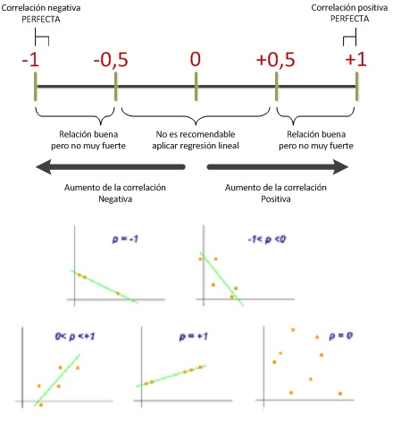

Aunque la interpretación de la magnitud del coeficiente de correlación depende del contexto particular de aplicación, en términos generales se considera que una correlación es baja por debajo de 0,30 en valor absoluto, que existe una asociación moderada entre 0,30 y 0,70, y alta por encima de 0,70.

## Regresión lineal simple

La regresión está dirigida a describir como es la **relación entre dos variables** $X$ e $Y$, de tal manera que incluso se pueden **hacer predicciones** sobre los valores de la variable $Y$, a partir de los de $X$. Cuando la asociación entre ambas variables es fuerte, la regresión nos ofrece un modelo estadístico que puede alcanzar finalidades predictivas.

La *regresión* supone que hay una variable fija, controlada por el investigador (es la variable independiente o predictora), y otra que *no está controlada* (variable respuesta o dependiente). La *correlación* supone que ninguna es fija: las dos variables están fuera del control de investigador.

La regresión es su forma más sencilla se llama **regresión lineal simple**. Se trata de una técnica estadística que analiza la relación entre **dos variables cuantitativas**, tratando de verificar si dicha **relación es lineal**. Si tenemos dos variables hablamos de *regresión simple*, si hay más de dos variables, hablamos de *regresión múltiple*.

Su objetivo es **explicar el comportamiento de una variable** $Y$, que denominaremos variable **explicada** (o **dependiente** o endógena), **a partir de otra variable** $X$, que llamaremos variable explicativa (o **independiente** o exógena).

Una vez que hemos hecho el diagrama de dispersión y después de observar una posible relación lineal entre las dos variables, nos proponemos encontrar la ecuación de la recta que mejor se ajuste a la nube de puntos. Esta recta se denomina **recta de regresión**.

### Método de los mínimos cuadrados

La **regresión lineal** consiste en encontrar (aproximar) los valores de una variable a partir de los de otra, usando una relación funcional de tipo lineal, es decir, buscamos números $a$ (ordenada en el origen) y $b$ (pendiente de la recta lineal) tales que se pueda escribir $\hat{Y} = a + bX$, con el menor error posible entre $\hat{Y}$ e $Y$.

Para cada observación podemos definir el **error** o residuo como la **distancia vertical** entre el punto $(x_i, y_i)$ y la recta, es decir: $y_i – (a + bx_i)$

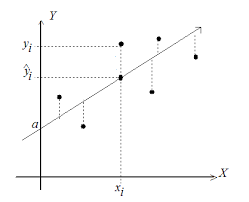

Los valores de $a$ y $b$ que minimizan el error son los llamados **coeficientes de regresión**:

$$b = \frac{S_{xy}}{S_x^2} \qquad a = \bar{y} - b\bar{x}$$

La cantidad b se denomina *“coeficiente de regresión de Y sobre X”*.

### Interpretación de la pendiente de la recta b

El coeficiente de regresión es muy importante, porque **mide el cambio de la variable $Y$ por cada unidad de cambio de $X$**. Este parámetro nos informa de cómo están relacionadas las dos variables en el sentido de que nos indica en qué cantidad (y si es positiva o negativa) varían los valores de $Y$ cuando varían los valores de la $X$. De hecho el coeficiente de regresión $b$ y el coeficiente de correlación $r$ siempre tendrán el mismo signo.

- Si $b > 0$, cada aumento de $X$ se corresponde con un aumento de $Y$;
- Si $b < 0$, $Y$ decrece a medida que aumenta $X$.

> El **método de los mínimos cuadrados** consiste en buscar los valores de los parámetros $a$ y $b$ de manera que la suma de los cuadrados de los residuos sea mínima. Esta recta es la **recta de regresión** por mínimos cuadrados.

### El coeficiente de determinación, $R^2$

Queremos evaluar en qué grado el modelo de regresión lineal que hemos encontrado a partir de un conjunto de observaciones explica las variaciones que se producen en la variable dependiente de éstas.

La medida más importante de la bondad del ajuste es el **coeficiente de determinación** $R^2$.

Este coeficiente nos indica el grado de ajuste de la recta de regresión a los valores de la muestra, y se define como el **porcentaje de la variabilidad total de la variable dependiente $Y$ que es explicada por la recta de regresión**.

La fórmula para calcular este coeficiente es la siguiente:

$$R^2 = 1 - \frac{S_e^2}{S_Y^2}$$

Las características de este coeficiente son:

- $R^2$ es una cantidad adimensional que sólo puede tomar valores en $[0, 1]$
- Cuando un ajuste es bueno, $R^2$ será cercano a uno (mayor será la fuerza de asociación entre ambas variables)
- Cuando un ajuste es malo, $R^2$ será cercano a cero (la recta no explica nada, no existe asociación entre $X$ e $Y$)

Puesto que $R^2$ nos presenta la proporción de variabilidad de los datos que queda explicada por el modelo de regresión, cuanto más cercano a uno esté, mejor es el ajuste.

### Relación entre $R^2$ y $r$

Es muy importante tener clara la diferencia entre el coeficiente de correlación y el coeficiente de determinación:

- $R^2$: mide la proporción de variación de la variable dependiente explicada por la variable independiente.
- $r$: mide el grado de asociación entre las dos variables.

No obstante, en la regresión lineal simple tenemos que $R^2 = r^2$.

Esta relación nos ayuda a comprender por qué antes considerábamos que un valor de $r = 0,5$ era débil. Este valor representará un $R^2 = 0,25$, es decir, el modelo de regresión sólo nos explica un 25% de la variabilidad total de las observaciones.

## Correlación lineal y regresión lineal en R

**Ejemplo 1**

La siguiente tabla muestra información sobre la edad y la presión sanguínea de 10 mujeres:

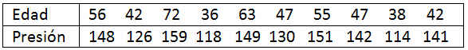

Datos del ejemplo1

En primer lugar, vamos a almacenar los datos de las dos variables en dos vectores.

```r
edad <- c(56, 42, 72,  36, 63, 47, 55, 47, 38, 42)
presion <- c(148, 126, 159, 118, 149, 130, 151, 142, 114, 141)
```

Supongamos que nuestro objetivo es determinar la edad de una mujer a partir de su presión sanguínea o, lo que es lo mismo, supongamos que la variable dependiente es **edad** y que la variable independiente es **presión**. Vamos a representar el diagrama de dispersión de las dos variables para determinar si la relación existente entre ambas puede considerarse lineal, y por tanto, tiene sentido plantear un modelo de regresión lineal simple.

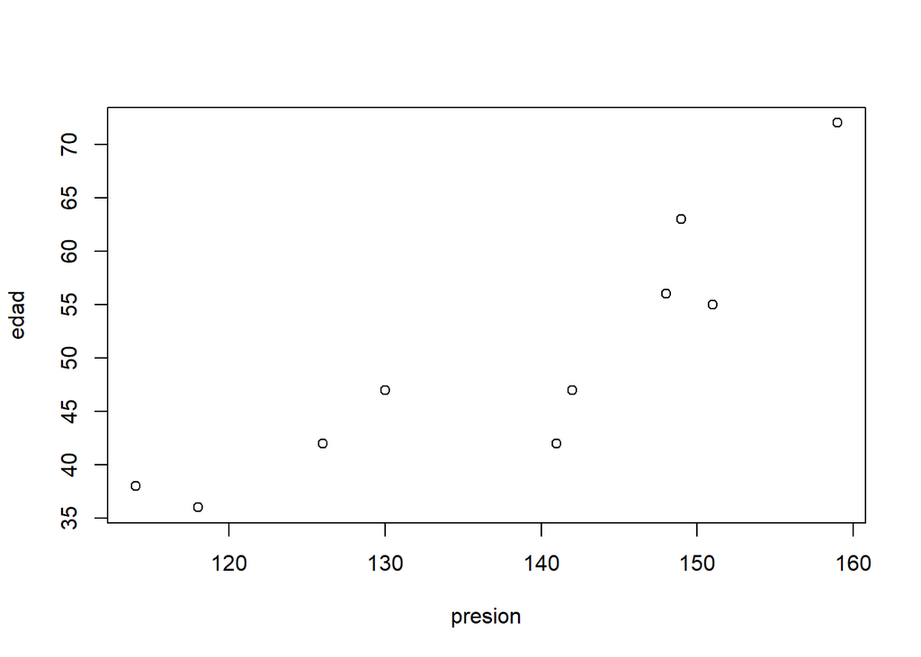

```r
plot(presion, edad)
```

A la vista del gráfico de dispersión, se puede asumir un cierto grado de relación lineal entre ambas variables, pero confirmemos utilizando el **coeficiente de correlación de Pearson** la fortaleza de asociación lineal entre ambas variables.

```r
# Hallamos el coeficiente de correlación lineal de Pearson
cor(presion, edad)
```

```
## [1] 0.8832662
```

Como vemos, el coeficiente anteriormente obtenido ($0.8832$) es bastante cercano a $1$, lo que nos indica que hay una fuerte relación lineal entre las dos variables, *presión* y *edad*, además por ser un número positivo, podemos concluir que la relación es creciente: a mayor presión, mayor edad y viceversa.

Ahora vamos a encontrar el modelo de regresión lineal para las dos variables anteriores.

```r
# La variable dependiente es la edad y la independiente es la presión. El orden importa
modelo <- lm(edad ~ presion)
modelo
```

```
##
## Call:
## lm(formula = edad ~ presion)
##
## Coefficients:
## (Intercept)      presion
##    -43.5440       0.6774
```

Lo que obtenemos con la operación `lm` son los parámetros de la ecuación lineal, en nuestro caso serían los valores de las variables $a$ y $b$. Por tanto, el modelo anterior se puede escribir como la siguiente ecuación:

$$\textrm{edad} = -43.5440 + 0.6774 \times \textrm{presion}$$

Estos dos parámetros pueden interpretarse del siguiente modo: $–43.5440$ es el valor de la edad para una persona de presión sanguínea $0$, lo cual no tiene sentido. De hecho, en multitud de ocasiones la interpretación del parámetro $a$ no es relevante y todo el interés recae sobre la interpretación del resto de parámetros.

El parámetro $b$ es igual a $0.6774$, lo que indica que, por término medio, cada mmHg (milímetros de mercurio) de incremento en la presión sanguínea de una persona supone un incremento de $0.6774$ en su edad.

Podemos obtener más información sobre el modelo de regresión que hemos calculado aplicando la función `summary` al objeto que contiene los datos de la regresión, al cual hemos llamado `modelo` en este ejemplo:

```r
summary(modelo)
```

```
##
## Call:
## lm(formula = edad ~ presion)
##
## Residuals:
##     Min      1Q  Median      3Q     Max
## -9.9676 -2.9835 -0.0973  3.8623  7.8394
##
## Coefficients:
##             Estimate Std. Error t value Pr(>|t|)
## (Intercept) -43.5440    17.6126  -2.472 0.038571 *
## presion       0.6774     0.1271   5.328 0.000704 ***
## ---
## Signif. codes:  0 '***' 0.001 '**' 0.01 '*' 0.05 '.' 0.1 ' ' 1
##
## Residual standard error: 5.742 on 8 degrees of freedom
## Multiple R-squared:  0.7802, Adjusted R-squared:  0.7527
## F-statistic: 28.39 on 1 and 8 DF,  p-value: 0.000704
```

Aquí obtenemos mucha información sobre el modelo de regresión lineal que realizamos. En nuestro caso vamos a ponerle especial atención al valor de $R^2$ (*Multiple R-squared*) y de $R^2$ ajustado (*Adjusted R-squared*), que son indicadores de la bondad del ajuste de nuestro modelo a los datos. Como hemos visto, $R^2$ oscila entre $0$ y $1$, de manera que, valores de $R^2$ próximos a $1$ indican un buen ajuste del modelo lineal a los datos. Por otro lado, $R^2$ ajustado es similar a $R^2$, pero penaliza la introducción en el modelo de variables independientes poco relevantes a la hora de explicar la variable dependiente. Por tanto, tenemos que $R^2 \textrm{ ajustado} \leq R^2$. En nuestro ejemplo, $R^2 = 0.7802$ y $R^2 \textrm{ ajustado} = 0.7527$, por lo que podemos concluir que el modelo lineal se ajusta de forma aceptable a nuestros datos.

R nos permiten dibujar la recta de regresión lineal sobre el diagrama de dispersión mediante la operación `abline`. De este modo podemos visualizar la distancia existente entre los valores observados y los valores que el modelo pronostica (esto es, los residuos).

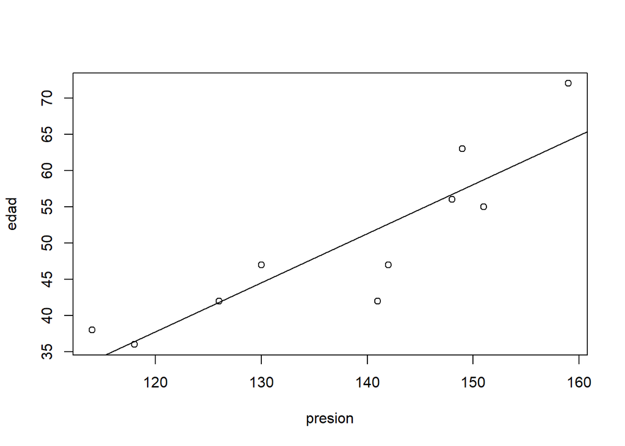

```r
# Presentamos el diagrama de dispersión de la presion y la edad
plot(presion, edad)

# Y ahora dibujamos la recta de regresión representada en el modelo
abline(modelo)
```

Pero uno de los *superpoderes* de la regresión lineal, es su capacidad de predicción. ¿Que pasa si queremos estimar la edad de una mujer que tiene una presión sanguínea en $142$? Una forma es reemplazar este valor en la ecuación de la edad que obtuvimos anteriormente. Otra opción es utilizar la operación `predict` que nos ofrece R.

```r
predict(modelo, data.frame(presion = 142))
```

```
##        1
## 52.64503
```

El valor que acabamos de obtener, $52.64503$, es la edad *estimada* de una mujer que tiene la presión en $142$.